# Sessão 5.3: Boxplots para Visualização de Distribuição e Outliers

Norberto Jorge Gonçalves

6 de Julho de 2025

# 1. Boxplots para Visualização de Distribuição e Outliers

Os boxplots (diagramas de caixa e bigodes) são gráficos muito úteis para visualizar a distribuição de uma variável numérica e identificar outliers, especialmente quando se compara a distribuição entre diferentes grupos categóricos.

## 1.1. O que um Boxplot nos Mostra?

Um boxplot resume a distribuição de uma variável numérica usando cinco números principais:

- Linha do Meio da Caixa: Mediana (Q2 - 50º percentil).
- Fundo da Caixa: Primeiro Quartil (Q1 - 25º percentil).
- Topo da Caixa: Terceiro Quartil (Q3 - 75º percentil).
- Comprimento da Caixa: Intervalo Interquartil (IQR = Q3 - Q1).
- Bigodes (Whiskers): Estendem-se até 1.5timesIQR do Q1 e Q3, ou até o valor mais extremo dentro desse limite.
- Pontos Fora dos Bigodes: São considerados outliers (valores extremos). Vamos usar o dataset iris para demonstrar.

```r
library(ggplot2)
data(iris)
head(iris)
```

|  | Sepal.Length | Sepal.Width | Petal.Length | Petal.Width | Species |
| --- | --- | --- | --- | --- | --- |
| 1 | 5.1 | 3.5 | 1.4 | 0.2 | setosa |
| 2 | 4.9 | 3.0 | 1.4 | 0.2 | setosa |
| 3 | 4.7 | 3.2 | 1.3 | 0.2 | setosa |
| 4 | 4.6 | 3.1 | 1.5 | 0.2 | setosa |
| 5 | 5.0 | 3.6 | 1.4 | 0.2 | setosa |
| 6 | 5.4 | 3.9 | 1.7 | 0.4 | setosa |

## 1.2. Criar um Boxplot Simples (geom_boxplot())

Para criar um boxplot de uma única variável numérica, podemos mapear essa variável ao eixo Y e deixar o eixo X vazio (ou mapeá-lo a uma constante).

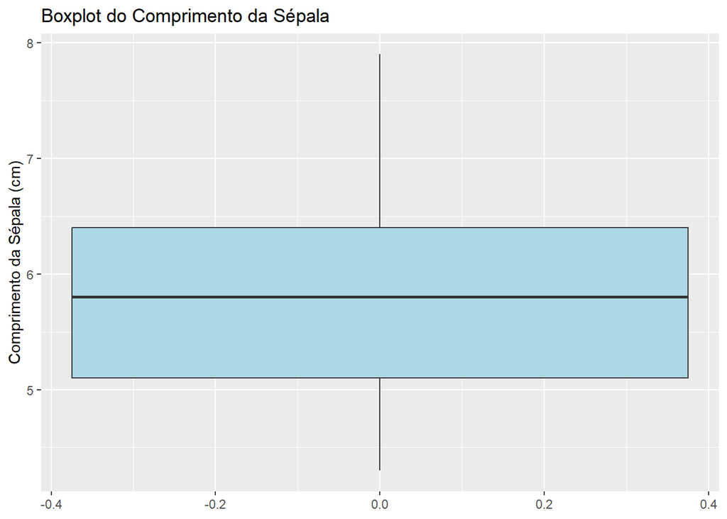

```r
ggplot(data = iris, aes(y = Sepal.Length)) +
  geom_boxplot(fill = "lightblue") +
  labs(
    title = "Boxplot do Comprimento da Sépala",
    y = "Comprimento da Sépala (cm)"
  )
```

## 1.3. Boxplots por Grupo Categórico

A maior utilidade dos boxplots é comparar a distribuição de uma variável numérica entre diferentes categorias. Mapeamos a variável categórica ao eixo X e a numérica ao eixo Y. Exemplo: Sepal.Length por Species no iris

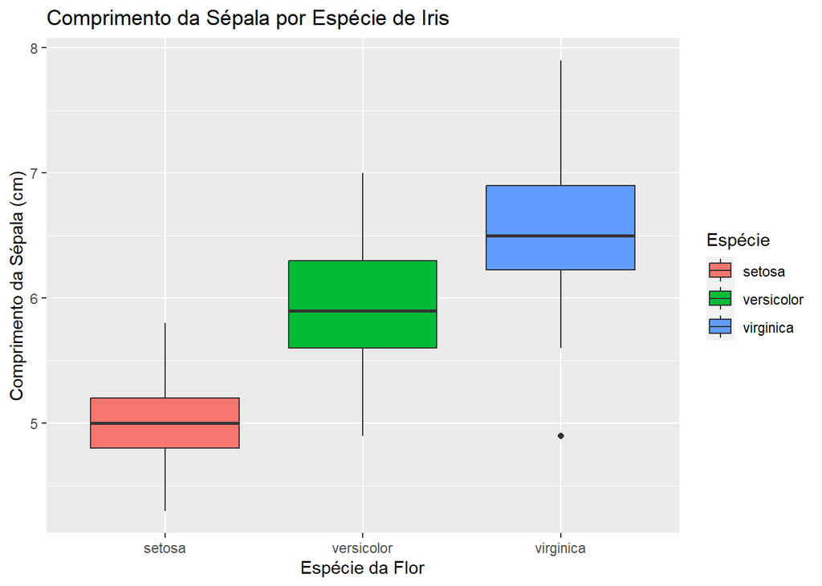

```r
ggplot(data = iris, aes(x = Species, y = Sepal.Length, fill = Species)) +
  geom_boxplot() +
  labs(
    title = "Comprimento da Sépala por Espécie de Iris",
    x = "Espécie da Flor",
    y = "Comprimento da Sépala (cm)",
    fill = "Espécie"
  )
```

Exemplo: mpg por cyl no mtcars

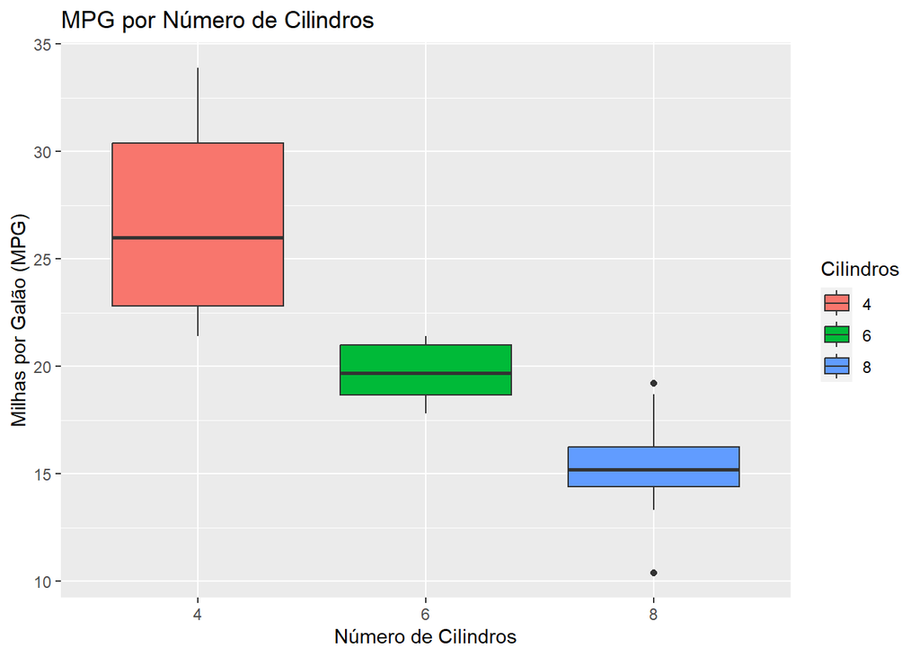

```r
data(mtcars)
# Converter cyl para fator para que o ggplot2 a trate como categórica
mtcars$cyl_factor <- as.factor(mtcars$cyl)

ggplot(data = mtcars, aes(x = cyl_factor, y = mpg, fill = cyl_factor)) +
  geom_boxplot() +
  labs(
    title = "MPG por Número de Cilindros",
    x = "Número de Cilindros",
    y = "Milhas por Galão (MPG)",
    fill = "Cilindros"
  )
```

## 1.4. Adicionar Pontos aos Boxplots (geom_jitter())

Para ver a distribuição exata dos pontos e a sobreposição, podemos adicionar geom_jitter() (pontos com um pequeno “ruído” para evitar sobreposição) aos boxplots.

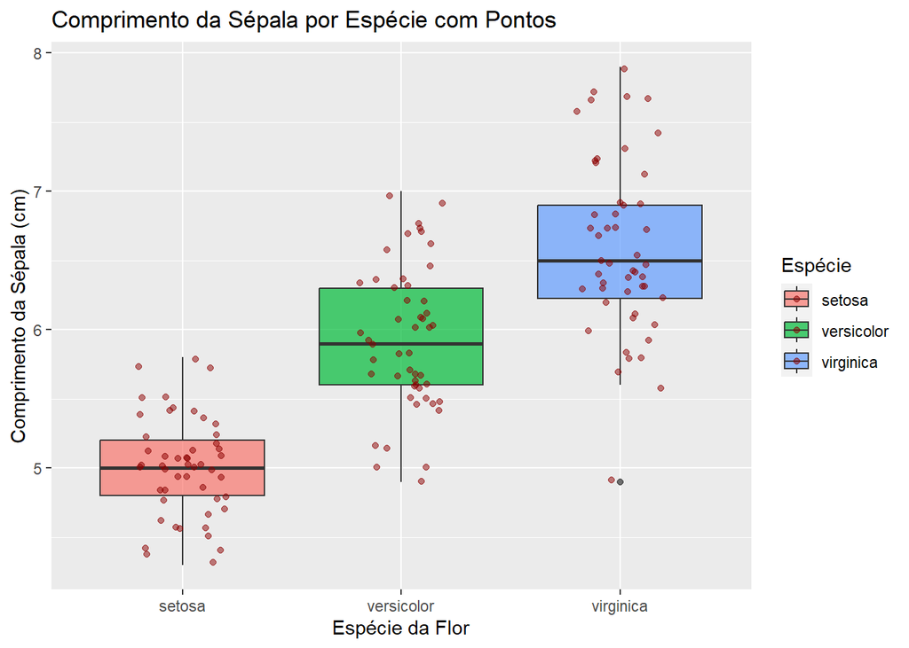

```r
ggplot(data = iris, aes(x = Species, y = Sepal.Length, fill = Species)) +
  geom_boxplot(alpha = 0.7) + # Transparência para ver os pontos por baixo
  geom_jitter(width = 0.2, alpha = 0.5, color = "darkred") + # width controla a dispersão horizontal dos pontos
  labs(
    title = "Comprimento da Sépala por Espécie com Pontos",
    x = "Espécie da Flor",
    y = "Comprimento da Sépala (cm)",
    fill = "Espécie"
  )
```

## 1.5. Inverter Eixos

Às vezes, é mais fácil ler os rótulos se os eixos forem invertidos.

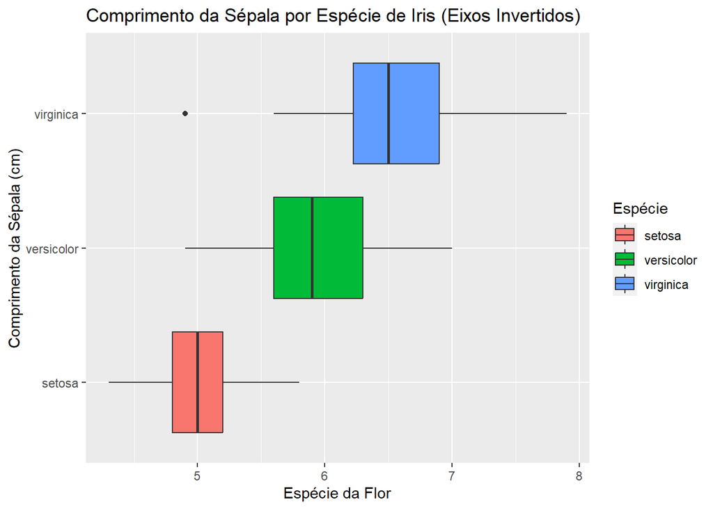

```r
ggplot(data = iris, aes(x = Species, y = Sepal.Length, fill = Species)) +
  geom_boxplot() +
  coord_flip() + # Inverte os eixos
  labs(
    title = "Comprimento da Sépala por Espécie de Iris (Eixos Invertidos)",
    y = "Espécie da Flor", # Y agora é a categoria
    x = "Comprimento da Sépala (cm)", # X agora é o valor numérico
    fill = "Espécie"
  )
```

________________________________________ *Parabéns!* Já dominam a criação e interpretação de boxplots!